# Laporan Capaian Output SAKTI 2024

Zaky Nur Kusmantoro

2024-05-12

## Definisi

**IKPA** adalah Indikator Kinerja Pelaksanaan Anggaran (IKPA) merupakan indikator yang penetapannya oleh Kementerian Keuangan selaku BUN untuk mengukur kualitas kinerja pelaksanaan anggaran belanja Kementerian Negara/Lembaga dari sisi kesesuaian terhadap perencanaan, efektivitas pelaksanaan anggaran, efisiensi pelaksanaan anggaran, dan kepatuhan terhadap regulasi.

Sesuai dengan Peraturan Direktur Jendral Perbendaharaan Nomor 5/PB/2022 tentang Petunjuk Teknis Penilaian Indikator Kinerja Pelaksanaan Anggaran (IKPA) Belanja Kementerian Negara/Lembaga terdapat beberapa aspek penilaian, salah satunya adalah **Aspek Kualitas Hasil Pelaksanaan Anggaran** yaitu Indikator kinerja Capaian Output

Bobot indikator kinerja Capaian Output dalam penilaian IPKA adalah sebesar 25% dan dengan proses bisnis Penilaian Indikator Kinerja adalah sebagai berikut

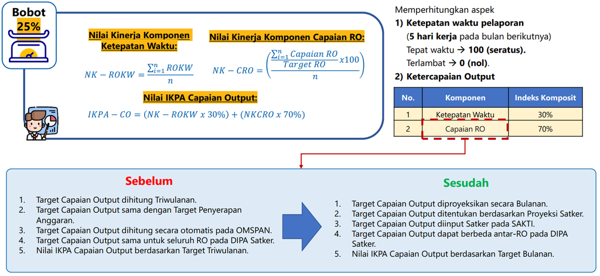

## Penjelasan Istilah

- **Klasifikasi Rincian Output**, Kumpulan atas output (Rincian Output) K/L yang disusun dengan mengelompokkan atau mengklasifikasikan muatan keluaran (output) yang sejenis/serumpun berdasarkan sektor/bidang/jenis tertentu secara sistematis
- **Rincian Output**, Keluaran (output) riil yang sangat spesifik yang dihasilkan oleh unit kerja K/L yang berfokus pada isu dan/atau lokasi tertentu serta berkaitan langsung dengan tugas dan fungsi unit kerja tersebut dalam mendukung pencapaian sasaran kegiatan yang ditetapkan.
- **Target Progres Capaian Rincian Output (PCRO)**, Persentase yang menunjukkan target tingkat penyelesaian dari berbagai tahapan atau aktivitas yang dilakukan Satker dalam mencapai suatu output riil/spesifik berupa barang/jasa.
- **Progres Capaian Rincian Output (PCRO)**, Persentase yang menunjukkan tingkat penyelesaian dari berbagai tahapan atau aktivitas yang dilakukan Satker dalam mencapai suatu output riil/spesifik berupa barang/jasa.
- **Target Rincian Volume Rincian Output (TRVRO)**, Target keluaran (output) riil berupa jumlah barang atau jasa yang dihasilkan oleh Satker atas penggunaan anggarannya
- **Rincian Volume Rincian Output**, Keluaran (output) riil berupa jumlah barang atau jasa yang dihasilkan oleh Satker atas penggunaan anggarannya

## Tabel Definisi Operasional RO Dit. SPO

| Klasifikasi Rincian Output | Rincian Output | Definisi Operasional | Satuan | Cara Perhitungan |
| --- | --- | --- | --- | --- |
| 4130.ABG - Kebijakan Bidang Kesehatan | 001 - Rekomendasi Kebijakan Keamanan, Mutu, Gizi dan Manfaat Pangan Olahan yang Diselesaikan | Rekomendasi kebijakan keamanan, mutu, gizi, dan manfaat pangan olahan dapat berupa rekomendasi kebijakan keamanan, mutu, gizi, manfaat dan label pangan olahan; rekomendasi kebijakan keamanan produk pa… | Rekomendasi Kebijakan | Berdasarkan rekomendasi kebijakan keamanan, mutu, gizi dan manfaat pangan olahan yang telah diselesaikan. |
| 4130.AFA - Norma, Standard, Prosedur dan Kriteria | 001 - Standar Pangan Olahan yang Disusun | Standar pangan olahan meliputi norma, standar, prosedur, dan kriteria (NSPK), diantaranya berupa peraturan, pedoman, standar, code of practice, atau policy paper/naskah kebijakan dibidang pangan olaha… | NSPK | Berdasarkan standar pangan olahan yang disusun sampai tahapan sesuai target; atau standar yang disusun sampai verbal (ditandatangani Direktur SPO) |
| 4130.CAB - Sarana Bidang Kesehatan | 001 - Sarana Pengawasan Pangan Olahan | Layanan sarana pelayanan pengawasan pangan olahan adalah pemenuhan sarana prasarana penunjang kinerja pengawasan pangan olahan sesuai kebutuhan yang merupakan hal mutlak untuk dipenuhi karena akan ber… | Unit | Realisasi dihitung berdasarkan progress kegiatan pengadaan barang/jasa |
| 4130.CAN - Sarana Bidang Teknologi Informasi dan Komunikasi | 001 - Perangkat pengolah data dan komunikasi | Layanan Pengadaan Perangkat Pengolah Data dan Komunikasi adalah pemenuhan sarana berupa Alat Pengolahan Data yang digunakan untuk menunjang kinerja | Unit | Jumlah perangkat pengolah data dan komunikasi |
| 3165.BDC - Fasilitasi dan Pembinaan Masyarakat | 001 - Masyarakat yang ditingkatkan pengetahuannya melalui KIE | - | Orang | NA |

## Tabel Informasi Target PCRO dan RVRO

### Target RVRO

| Klasifikasi Rincian Output | Rincian Output | Jenis Target | 01-January | 02-February | 03-March | 04-April | 05-May | 06-June | 07-July | 08-August | 09-September | 10-October | 11-November | 12-December |
| --- | --- | --- | --- | --- | --- | --- | --- | --- | --- | --- | --- | --- | --- | --- |
| 4130.ABG - Kebijakan Bidang Kesehatan | 001 - Rekomendasi Kebijakan Keamanan, Mutu, Gizi dan Manfaat Pangan Olahan yang Diselesaikan | Target RVRO Akumulasi | 21 | 39 | 52 | 58 | 66 | 74 | 87 | 101 | 113 | 136 | 160 | 189 |
| 4130.AFA - Norma, Standard, Prosedur dan Kriteria | 001 - Standar Pangan Olahan yang Disusun | Target RVRO Akumulasi | 0 | 0 | 0 | 0 | 0 | 0 | 0 | 0 | 0 | 0 | 0 | 11 |
| 4130.CAB - Sarana Bidang Kesehatan | 001 - Sarana Pengawasan Pangan Olahan | Target RVRO Akumulasi | 0 | 0 | 1 | 1 | 1 | 4 | 8 | 12 | 16 | 21 | 26 | 34 |
| 4130.CAN - Sarana Bidang Teknologi Informasi dan Komunikasi | 001 - Perangkat pengolah data dan komunikasi | Target RVRO Akumulasi | 0 | 0 | 13 | 17 | 17 | 19 | 29 | 39 | 49 | 64 | 93 | 129 |
| 3165.BDC - Fasilitasi dan Pembinaan Masyarakat | 001 - Masyarakat yang ditingkatkan pengetahuannya melalui KIE | Target RVRO Akumulasi | 500 | 500 | 500 | 500 | 500 | 500 | 750 | 1000 | 1250 | 1500 | 1750 | 1750 |

### Target PCRO

| Klasifikasi Rincian Output | Rincian Output | Jenis Target | 01-January | 02-February | 03-March | 04-April | 05-May | 06-June | 07-July | 08-August | 09-September | 10-October | 11-November | 12-December |
| --- | --- | --- | --- | --- | --- | --- | --- | --- | --- | --- | --- | --- | --- | --- |
| 4130.ABG - Kebijakan Bidang Kesehatan | 001 - Rekomendasi Kebijakan Keamanan, Mutu, Gizi dan Manfaat Pangan Olahan yang Diselesaikan | Target PCRO Akumulasi | 11.11 | 20.63 | 27.51 | 30.68 | 34.91 | 39.14 | 46.02 | 53.43 | 59.78 | 71.95 | 84.65 | 100 |
| 4130.AFA - Norma, Standard, Prosedur dan Kriteria | 001 - Standar Pangan Olahan yang Disusun | Target PCRO Akumulasi | 9 | 11 | 19 | 28 | 37 | 42 | 46 | 58 | 65 | 75 | 88 | 100 |
| 4130.CAB - Sarana Bidang Kesehatan | 001 - Sarana Pengawasan Pangan Olahan | Target PCRO Akumulasi | 0.95 | 1.95 | 2.95 | 3.95 | 4.95 | 11.77 | 23.53 | 35.29 | 47.05 | 61.76 | 76.47 | 100 |
| 4130.CAN - Sarana Bidang Teknologi Informasi dan Komunikasi | 001 - Perangkat pengolah data dan komunikasi | Target PCRO Akumulasi | 1 | 2 | 10.08 | 13.18 | 14.18 | 14.73 | 22.48 | 30.23 | 37.98 | 49.61 | 72.09 | 100 |
| 3165.BDC - Fasilitasi dan Pembinaan Masyarakat | 001 - Masyarakat yang ditingkatkan pengetahuannya melalui KIE | Target PCRO Akumulasi | 28.57 | 28.57 | 28.57 | 28.57 | 28.57 | 28.57 | 42.85 | 57.13 | 71.42 | 85.71 | 100 | 100 |

## Tabel Realisasi PCRO dan RVRO

| Klasifikasi Rincian Output | Rincian Output | Bulan | Target RVRO Akumulasi | Realisasi RVRO Akumulasi | Target PCRO Akumulasi | Realisasi PCRO Akumulasi | Pagu Anggaran | Realisasi Anggaran Akumulasi | Capaian | Gap | Bukti Dokumen | Keterangan |
| --- | --- | --- | --- | --- | --- | --- | --- | --- | --- | --- | --- | --- |
| 4130.ABG - Kebijakan Bidang Kesehatan | 001 - Rekomendasi Kebijakan Keamanan, Mutu, Gizi dan Manfaat Pangan Olahan yang Diselesaikan | 01-January | 21 | 21 | 11.11 | 11.11 | 447679000 | 7079000 | 1.58 | 9.53 | Rekomendasi Kebijakan | Layanan rekomendasi kebijakan keamanan mutu, gizi, dan manfaat pangan olahan sudah diselesaikan pada Januari adalah 21 kajian - Keamanan pangan 12 kajian selesai - Pangan Olahan Tertentu 5 kajian sele… |
| 4130.AFA - Norma, Standard, Prosedur dan Kriteria | 001 - Standar Pangan Olahan yang Disusun | 01-January | 0 | 0 | 9 | 9.62 | 5320629000 | 27519423 | 0.52 | 9.1 | NSPK | Realisasi hingga akhir Januari adalah 9,62% - Pengumpulan Data Materi dengan Stakeholder 11 dari 11 standar |
| 4130.CAB - Sarana Bidang Kesehatan | 001 - Sarana Pengawasan Pangan Olahan | 01-January | 0 | 0 | 0.95 | 0.95 | 268052000 | 0 | 0 | 0.95 | Dokumen Pengadaan | Masih dalam tahap perencanaan untuk melakukan pembelian fasilitas kantor |
| 4130.CAN - Sarana Bidang Teknologi Informasi dan Komunikasi | 001 - Perangkat pengolah data dan komunikasi | 01-January | 0 | 0 | 1 | 1 | 1481822000 | 0 | 0 | 1 | Dokumen Pengadaan | Masih dalam tahap perencanaan untuk melakukan pembelian alat pengolah data |
| 3165.BDC - Fasilitasi dan Pembinaan Masyarakat | 001 - Masyarakat yang ditingkatkan pengetahuannya melalui KIE | 01-January | 500 | 500 | 28.57 | 28.57 | 612290000 | 75000000 | 12.25 | 16.32 | Orang | Telah melaksanakan kegiatan KIE Tomas sebanyak 2 titik (500 peserta) di Tasikmalaya |
| 4130.ABG - Kebijakan Bidang Kesehatan | 001 - Rekomendasi Kebijakan Keamanan, Mutu, Gizi dan Manfaat Pangan Olahan yang Diselesaikan | 02-February | 39 | 39 | 20.63 | 20.63 | 447679000 | 13552000 | 3.03 | 17.61 | Rekomendasi Kebijakan | Layanan rekomendasi kebijakan keamanan mutu, gizi, dan manfaat pangan olahan sudah diselesaikan pada Februari adalah 18 kajian - Keamanan pangan 8 kajian selesai - Pangan Olahan Tertentu 5 kajian sele… |
| 4130.AFA - Norma, Standard, Prosedur dan Kriteria | 001 - Standar Pangan Olahan yang Disusun | 02-February | 0 | 0 | 11 | 15.93 | 5320629000 | 209589368 | 3.94 | 11.99 | NSPK | Realisasi hingga akhir Februari adalah 15,93% - Pengumpulan Data Materi dengan Stakeholder 6 dari 11 standar - Pengkajian Pustaka 3 dari 11 standar - Pembahasan Draft Awal 1 dari 11 standar |
| 4130.CAB - Sarana Bidang Kesehatan | 001 - Sarana Pengawasan Pangan Olahan | 02-February | 0 | 0 | 1.95 | 1.95 | 268052000 | 0 | 0 | 1.95 | Dokumen Pengadaan | Dalam tahap progres pembelian dan kontrak fasilitas kantor |
| 4130.CAN - Sarana Bidang Teknologi Informasi dan Komunikasi | 001 - Perangkat pengolah data dan komunikasi | 02-February | 0 | 0 | 2 | 2 | 1481822000 | 0 | 0 | 2 | Dokumen Pengadaan | Dalam tahap progres pembelian dan kontrak alat pengolah data |
| 3165.BDC - Fasilitasi dan Pembinaan Masyarakat | 001 - Masyarakat yang ditingkatkan pengetahuannya melalui KIE | 02-February | 500 | 500 | 28.57 | 28.57 | 612290000 | 126890000 | 20.72 | 7.85 | Orang | Tidak ada pelaksanaan kegiatan KIE pada bulan Februari |

[output cut: 10 more lines]

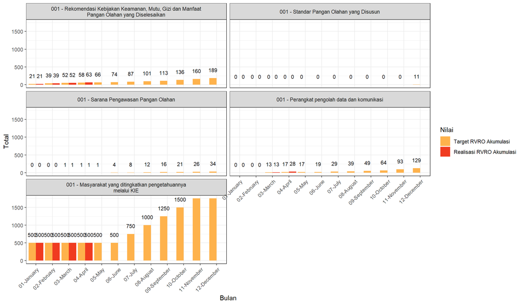

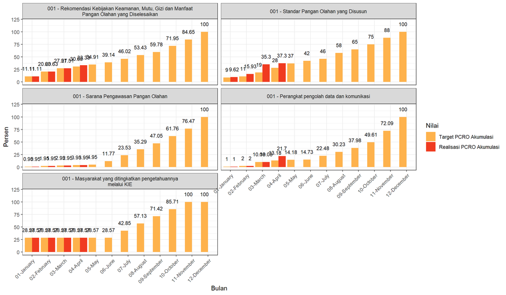